# Final Project - Tools for Data Science

Sofani Mesfun

2022

In this project you will be working with R, SQL, and Python in the same document. We will use the data sets *airlines* and *flights* from the package *nycflights13*.

1. *Knit* the empty file (to make sure everything is working)
2. Consistently *knit* the file each time you answer a question

⚠️ Students enrolled in CAP4755 should only solve: **questions 1 and 2**

**In R, install the packages `nycflights13`, `sqldf`, `tydiverse` and load all data sets and packages**. Take your time to understand the data sets.

```r
#Install code here - comment the code when you finish installation
#install.packages("nycflights13")
#install.packages("sqldf")
#install.packages("tidyverse")
#install.packages("seaborn")
#install.packages("dplyr")
# Load all packages here
library(nycflights13)
library(sqldf)
library(tidyverse)
library(ggplot2)
# Load the data here
data(nycflights13)
```

> **Question 1: List the name of airlines where the destination is ATL airport with their *average arrival delays* and sort them from the smallest to largest average arrival delays. Use data frames `flights` and `airlines`.**

We shall solve this question using R, SQL, and Python.

### R solution

You can use the R command `inner_join()` to join two tables.

```r
# Code here
ListOfFlightsAirLinesATL<-data.frame(inner_join(flights, airlines, by = 'carrier')
                           %>% filter(dest=="ATL")
                           %>% group_by(name)
                           %>% drop_na()
                           %>% summarise(Ave=mean(arr_delay))
                           %>% select(name, Ave)
                           %>% arrange(desc(-Ave))

              )
ListOfFlightsAirLinesATL
```

```
##                          name        Ave
## 1           Endeavor Air Inc.  0.8571429
## 2      Southwest Airlines Co.  6.8965517
## 3        Delta Air Lines Inc.  7.4242250
## 4       United Air Lines Inc. 10.5000000
## 5                   Envoy Air 14.0340045
## 6    ExpressJet Airlines Inc. 19.6382850
## 7 AirTran Airways Corporation 20.7445127
```

### SQL solution

Write your SQL query in the function `sqldf()`. For exmaple,`sqldf("select * from relig_income")` list the data frame `relig_income`.

```r
# Example
#sqldf("select * from relig_income limit 3")
# code here
df_flightsdata<-data.frame(flights)
df_airlinesdata <-data.frame(airlines)

sqldf("select  name, avg(arr_delay) as AVE from df_flightsdata
       INNER JOIN df_airlinesdata
       on df_flightsdata.carrier = df_airlinesdata.carrier
       where dest = 'ATL'
       group by name
       order by AVE ASC")
```

```
##                          name        AVE
## 1           Endeavor Air Inc.  0.8571429
## 2      Southwest Airlines Co.  6.8965517
## 3        Delta Air Lines Inc.  7.4242250
## 4       United Air Lines Inc. 10.5000000
## 5                   Envoy Air 14.0340045
## 6    ExpressJet Airlines Inc. 19.6382850
## 7 AirTran Airways Corporation 20.7445127
```

### Python solution

Use [df.join()](https://pandas.pydata.org/docs/reference/api/pandas.DataFrame.join.html) from pandas.

```python
# load python libraries
import pandas as pd
from nycflights13 import flights
from nycflights13 import airlines

# load data
df_airlines = pd.DataFrame(airlines)
df_flights = pd.DataFrame(flights)
# code here
ListOfFlightsAirLinesATLPython = df_flights.merge(df_airlines, how='inner', on='carrier')
ListOfFlightsAirLinesATLPython.query("dest == 'ATL'", inplace=True )
ListOfFlightsAirLinesATLPython.groupby(by = ['name'])['arr_delay'].mean().sort_values(ascending=True)
```

```
## name
## Endeavor Air Inc.               0.857143
## Southwest Airlines Co.          6.896552
## Delta Air Lines Inc.            7.424225
## United Air Lines Inc.          10.500000
## Envoy Air                      14.034004
## ExpressJet Airlines Inc.       19.638285
## AirTran Airways Corporation    20.744513
## Name: arr_delay, dtype: float64
```

> **Question 2: Plot the boxplot of the departure delays vs the name of airlines where the destination is ATL airport. Solve this question using R and Python.**

### R solution

Use ggplot

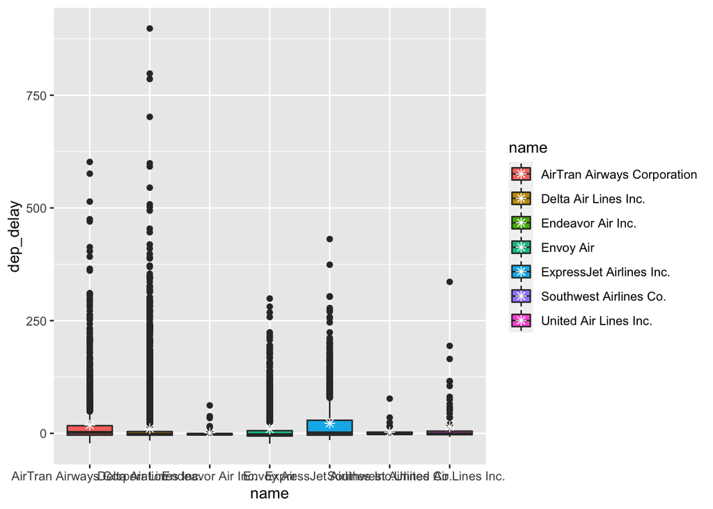

```r
library(dplyr, warn.conflicts = FALSE)
# Suppress summarise info
options(dplyr.summarise.inform = FALSE)
# code here
departuredelayNameofAirlineATL<-data.frame(inner_join(flights, airlines, by = 'carrier')
                           %>% filter(dest=="ATL")
                           %>% group_by(name)
                           %>% drop_na()
                           %>% summarise(dep_delay)
              )
ggplot(departuredelayNameofAirlineATL, aes(x = name, y = dep_delay,  fill = name)) + geom_boxplot() +
   stat_summary(fun = "mean", geom = "point", shape = 8,
               size = 2, color = "white")
```

### Python solution

You can use [pandas.boxplot()](https://pandas.pydata.org/docs/reference/api/pandas.DataFrame.boxplot.html) or [seaborn.boxplot()](https://seaborn.pydata.org/generated/seaborn.boxplot.html). You can either import data from the R package into Python or use the data Python package [nycflights13](https://pypi.org/project/nycflights13/)

```python
# import python libraries
import matplotlib.pyplot as plt
import seaborn as sns
import pandas as pd
# data
df_airlines = pd.DataFrame(airlines)
df_flights = pd.DataFrame(flights)
departuredelayNameofAirlineATLPython= df_flights.merge(df_airlines, how='inner', on='carrier')
departuredelayNameofAirlineATLPython.query("dest == 'ATL'", inplace=True )
departuredelayNameofAirlineATLPython.groupby('name')[('dep_delay')].aggregate('min')
# Boxplot
# code here
```

```
## name
## AirTran Airways Corporation   -22.0
## Delta Air Lines Inc.          -16.0
## Endeavor Air Inc.              -6.0
## Envoy Air                     -23.0
## ExpressJet Airlines Inc.      -15.0
## Southwest Airlines Co.         -7.0
## United Air Lines Inc.          -8.0
## Name: dep_delay, dtype: float64
```

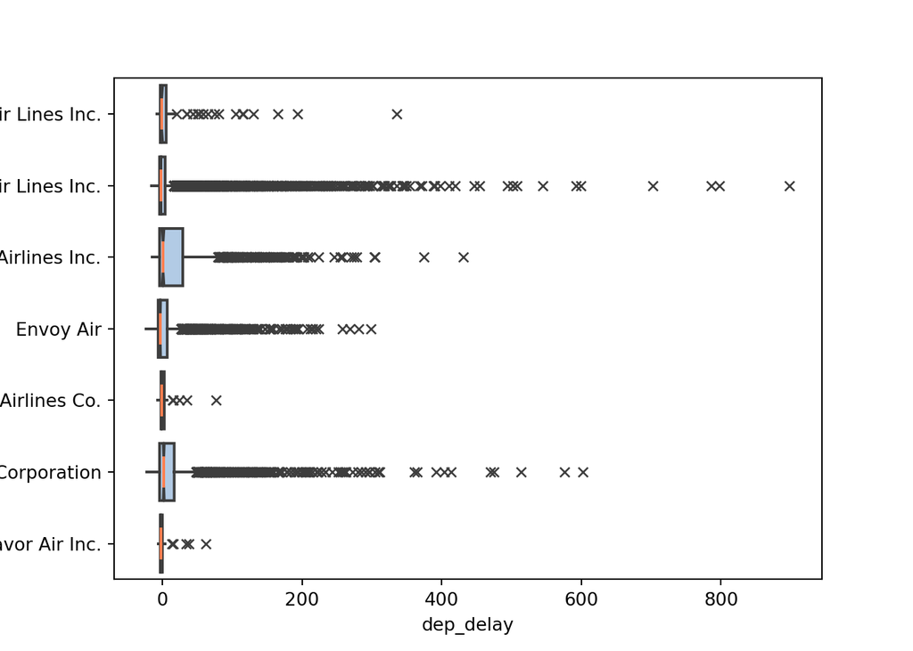

```python
sns.boxplot(
    data=departuredelayNameofAirlineATLPython, y="name", x="dep_delay",
     notch=True, showcaps=False,
    flierprops={"marker": "x"},
    boxprops={"facecolor": (.4, .6, .8, .5)},
    medianprops={"color": "coral"},
  )
plt.show()
```

> **Question 3: For each airlines, 1) find the month where the average departure time is the highest in the year. 2) Make a visualization to show the results. Solve this question using your preferred language R or Python.**

```r
# Do not foget to specify which language are you using.

# load libraries
library(nycflights13)
library(tidyverse)
library(dplyr, warn.conflicts = FALSE)


# Suppress summarise info
options(dplyr.summarise.inform = FALSE)
# load data
data(nycflights13)
# code here to find the months

Averagedeparturetime <- merge(airlines, flights, by ="carrier")
Averagedeparturetime %>%
  group_by(name, month) %>%
  drop_na()  %>%
  summarise(mean_dt= mean(dep_time)) %>%
  arrange(desc(mean_dt))%>%
  slice_max(mean_dt)
```

```
## # A tibble: 16 × 3
## # Groups:   name [16]
##    name                        month mean_dt
##    <chr>                       <int>   <dbl>
##  1 AirTran Airways Corporation    12   1488.
##  2 Alaska Airlines Inc.           12   1374.
##  3 American Airlines Inc.          1   1301.
##  4 Delta Air Lines Inc.            7   1361.
##  5 Endeavor Air Inc.               5   1535.
##  6 Envoy Air                      12   1408.
##  7 ExpressJet Airlines Inc.        1   1406.
##  8 Frontier Airlines Inc.          6   1597.
##  9 Hawaiian Airlines Inc.          8    973.
## 10 JetBlue Airways                12   1399.
## 11 Mesa Airlines Inc.              9   1762.
## 12 SkyWest Airlines Inc.           8   1889
## 13 Southwest Airlines Co.         12   1298.
## 14 United Air Lines Inc.           6   1364.
## 15 US Airways Inc.                 3   1243.
## 16 Virgin America                  7   1325.
```

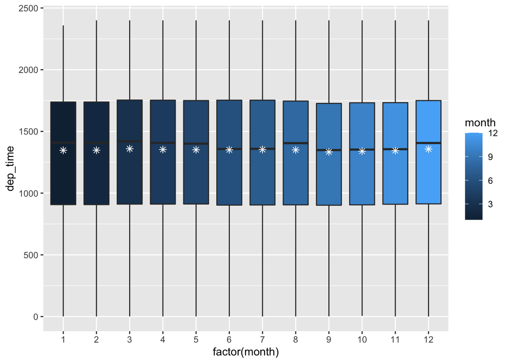

```r
# code here to make the visualization

ggplot(Averagedeparturetime, aes(x = factor(month), y = dep_time,  fill = month)) + geom_boxplot() +
   stat_summary(fun = "mean", geom = "point", shape = 8,
               size = 2, color = "white")
```